# Презентация по лабораторной работе №5

Дискреционное разграничение прав в Linux. Исследование влияния дополнительных атрибутов

Лушин А.А.

Российский университет дружбы народов, Москва, Россия

Факультет Физико-математических и естественных наук

# Информация

## Докладчик

- Лушин Артём Андреевич
- Бакалавр направления компьютерные и информационные науки
- Кафедра теории вероятности и кибербезопасности
- Российский университет дружбы народов
- Редактор Первого Федерального канала
- lusin5745@gmail.com

# Вводная часть

## Цели и задачи

- Изучение механизмов изменения идентификаторов, применения SetUID- и Sticky-битов. Получение практических навыков работы в консоли с дополнительными атрибутами. Рассмотрение работы механизма смены идентификатора процессов пользователей, а также влияние бита Sticky на запись и удаление файлов.

# Ход работы

# Создание программы

## Созданий программ в целом

Для начала работы мы должны создать файл “simpleid.c”. В этот файл просто вписываем код, основанный на языке С++.

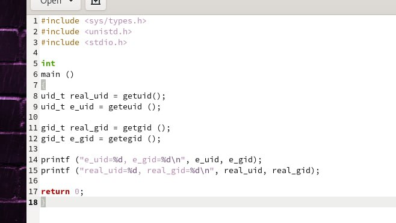

## Компиляция программы

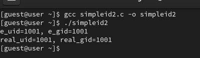

## Смена владельца файла

Так как мы создавали программу, используя аккаунт “guest”, то и владельцем файла является “guest”. Но с помощью команды “chown root:guest имя_файла” мы меняем владельца файла. Теперь файл принадлежит root пользователя. Так же с помощью команды “chmod g+s” мы сделали Setgid-бит. То есть все файлы и директории, который будут созданы, будут наследовать идентификаторы группы каталога, а не идентификатор группы пользователя, который создал файл.

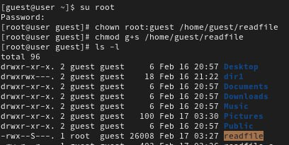

## Запуск программы

Из-за того, что мы сделали владельцем файла root, то и работать с файлом мы можем только с аккаунта root. Если мы попытаемся запустить программу с аккаунт “guest” или какого-то другого, то у нас просто вылезет ошибка, что нет доступа.

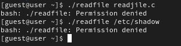

# Исследование Sticky-бита

## Проверка бита

Чтобы определить есть ли у директории sticky-бит (t) или нет, нам необходимо ввести команду “ls -l”” | grep имя_директории”. Если в конце стоит “t”, то бит включён, а если нет, то мы можем его включить с помощью команды “chmod +t имя_файла”. При этом необходимо быть суперпользователем.

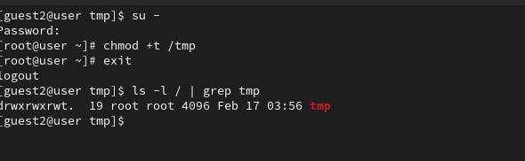

## Возможности Sticky-бита

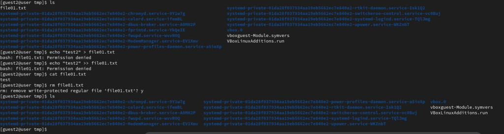

# Важное примечание

В ходе лабораторной работы я проверял работу бита с помощью аккаунт “guest2”, который находится в группе с акаунтом “guest”. Я выдал права на категорию “все остальные” для редактирования файла. Но мой аккаунт находился в категории “группа владельца” и на него эти права не распространялись. То есть я не смог проверить, можно ли редактировать файл, используя бит. Но в данных из интернета написано, что Sticky-бит не влияет на возможность редактирования файла, а только на удаление его.

# Результаты